# Programming_Assignment_3

suveyda

January 18, 2017

# Programming Assignment 3: Hospital Quality

## R Programming by Johns Hopkins University

### Introduction

In this programming assignment we will examine a data from the Hospital Compare web site (http://hospitalcompare.hhs.gov) run by the U.S. Department of Health and Human Services. The purpose of the web site is to provide data and information about the quality of care at over 4,000 Medicare-certified hospitals in the U.S. This dataset essentially covers all major U.S. hospitals. This dataset is used for a variety of purposes, including determining whether hospitals should be fined for not providing high quality care to patients.

### Data

You can download the ProgAssignment3-data.zip file containing the data for Programming Assignment 3 from the Coursera web site. The Hospital Compare web site contains a lot of data and we will only look at a small subset for this assignment. The zip file for this assignment contains three files:

- outcome-of-care-measures.csv: Contains information about 30-day mortality and readmission rates for heart attacks, heart failure, and pneumonia for over 4,000 hospitals.
- hospital-data.csv: Contains information about each hospital.
- Hospital_Revised_Flatfiles.pdf: Descriptions of the variables in each file (i.e the code book).

### Plot the 30-day mortality rates for heart attack

Let’s first read the data into R

```r
outcome <- read.csv("outcome-of-care-measures.csv", colClasses = "character")
ncol(outcome)
```

```
## [1] 46
```

```r
nrow(outcome)
```

```
## [1] 4706
```

There are 46 columns and 4706 rows in this dataset. Also the names of the columns are:

```r
names(outcome)
```

```
##  [1] "Provider.Number"
##  [2] "Hospital.Name"
##  [3] "Address.1"
##  [4] "Address.2"
##  [5] "Address.3"
##  [6] "City"
##  [7] "State"
##  [8] "ZIP.Code"
##  [9] "County.Name"
## [10] "Phone.Number"
## [11] "Hospital.30.Day.Death..Mortality..Rates.from.Heart.Attack"
## [12] "Comparison.to.U.S..Rate...Hospital.30.Day.Death..Mortality..Rates.from.Heart.Attack"
## [13] "Lower.Mortality.Estimate...Hospital.30.Day.Death..Mortality..Rates.from.Heart.Attack"
## [14] "Upper.Mortality.Estimate...Hospital.30.Day.Death..Mortality..Rates.from.Heart.Attack"
## [15] "Number.of.Patients...Hospital.30.Day.Death..Mortality..Rates.from.Heart.Attack"
```

[output cut: 31 more lines]

In this part we just make a simple histogram of the 30-day death rates from heart attack (column 11 in the outcome dataset).

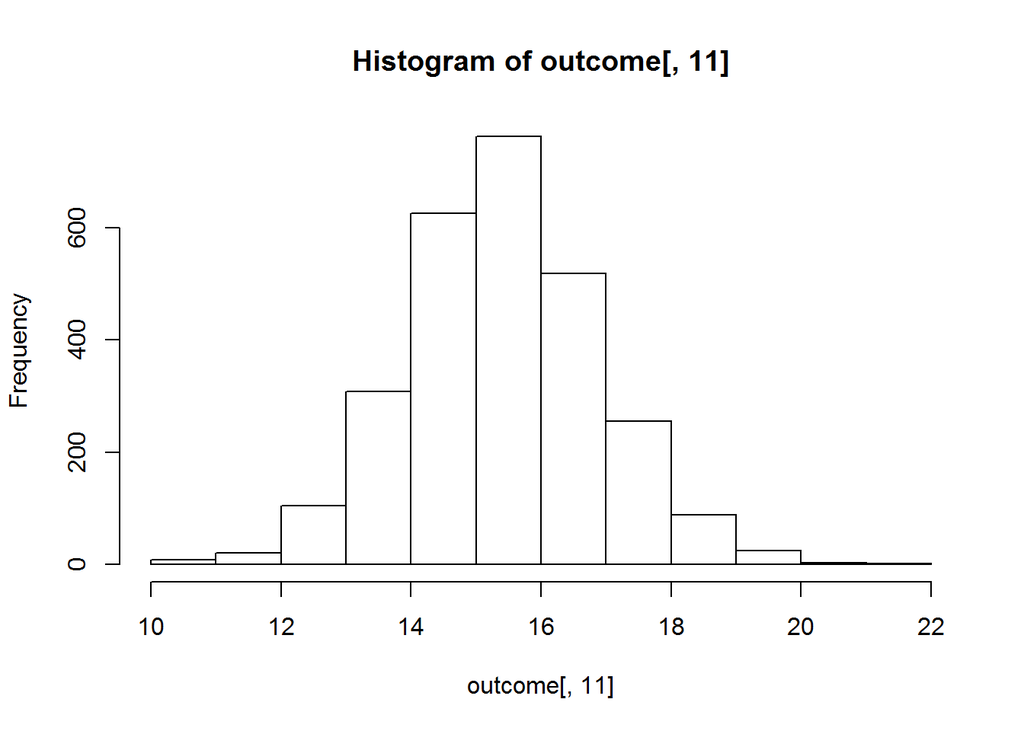

```r
outcome[, 11] <- as.numeric(outcome[, 11])
hist(outcome[, 11])
```

### Finding the best hospital in a state

In this part we need to write a function called **‘best’** that take two arguments: the 2-character abbreviated name of a state and an outcome name. The function reads the outcome-of-care-measures.csv file and returns a character vector with the name of the hospital that has the best 30-day mortality for the specified outcome in that state. The hospital name is the name provided in the Hospital.Name variable. The outcomes can be one of **‘heart attack’**, **‘heart failure’**, or **‘pneumonia’**. Hospitals that do not have data on a particular outcome will be excluded from the set of hospitals when deciding the rankings.

If there is a tie for the best hospital for a given outcome, then the hospital names will be sorted in alphabetical order and the first hospital in that set will be chosen.

Furthermore, the function will check the validity of its arguments. The function will throw an error message if an invalid state value or an invalid outcome value is passed to the function.

For this function we use the below columns:

- [2] Hospital Name: varchar (50) Lists the name of the hospital.
- [7] State: varchar (2) Lists the 2 letter State code in which the hospital is located.
- [11] Hospital 30-Day Death (Mortality) Rates from Heart Attack: Lists the risk adjusted rate (percentage) for each hospital.
- [17] Hospital 30-Day Death (Mortality) Rates from Heart Failure: Lists the risk adjusted rate (percentage) for each hospital.
- [23] Hospital 30-Day Death (Mortality) Rates from Pneumonia: Lists the risk adjusted rate (percentage) for each hospital.

```r
best <- function(state, outcome) {
    data <- read.csv("outcome-of-care-measures.csv", colClasses = "character")
    state_vec <- unique(data[,7])

    if(state %in% state_vec) {
        if(outcome == "heart attack" || outcome == "heart failure" || outcome == "pneumonia") {
            if(outcome == "heart attack")
                subdata <- data[data[,7] == state, c(2,7,11)]
            else if(outcome == "heart failure")
                subdata <- data[data[,7] == state, c(2,7,17)]
            else
                subdata <- data[data[,7] == state, c(2,7,23)]

            subdata[, 3] <- as.numeric(subdata[,3])
            subdata_2 <- subdata[!is.na(subdata[,3]),]
            minimum <- min(subdata_2[,3])
            result_vec <- sort(subdata_2[subdata_2[,3] == minimum, 1])

            result_vec[1]
        } else {
            stop("invalid outcome")
        }
    } else {
        stop("invalid state")
    }
}
```

Here is some sample output from the function:

```r
best("TX", "heart attack")
```

```
## [1] "CYPRESS FAIRBANKS MEDICAL CENTER"
```

```r
best("TX", "heart failure")
```

```
## [1] "FORT DUNCAN MEDICAL CENTER"
```

```r
best("MD", "heart attack")
```

```
## [1] "JOHNS HOPKINS HOSPITAL, THE"
```

```r
best("MD", "pneumonia")
```

```
## [1] "GREATER BALTIMORE MEDICAL CENTER"
```

```r
#best("BB", "heart attack")
#best("NY", "hert attack")
best("SC", "heart attack")
```

```
## [1] "MUSC MEDICAL CENTER"
```

```r
best("NY", "pneumonia")
```

```
## [1] "MAIMONIDES MEDICAL CENTER"
```

```r
best("AK", "pneumonia")
```

```
## [1] "YUKON KUSKOKWIM DELTA REG HOSPITAL"
```

### Ranking hospitals by outcome in a state

In this part we write a function called **‘rankhospital’** that takes three arguments: the 2-character abbreviated name of a state (state), an outcome (outcome), and the ranking of a hospital in that state for that outcome (num).

The function reads the outcome-of-care-measures.csv file and returns a character vector with the name of the hospital that has the ranking specified by the num argument. The num argument can take values **‘best’**, **‘worst’**, or **an integer** indicating the ranking. If the number given by num is larger than the number of hospitals in that state, then the function will return NA. Hospitals that do not have data on a particular outcome will be excluded from the set of hospitals when deciding the rankings.

It may occur that multiple hospitals have the same 30-day mortality rate for a given cause of death. In those cases ties will be broken by using the hospital name.

For this function we use the same columns from before. Please see the function below:

```r
rankhospital <- function(state, outcome, num = "best") {
    data <- read.csv("outcome-of-care-measures.csv", colClasses = "character")
    state_vec <- unique(data[,7])

    if(state %in% state_vec) {
        if(outcome == "heart attack" || outcome == "heart failure" || outcome == "pneumonia") {
            if(outcome == "heart attack")
                subdata <- data[data[,7] == state, c(2,7,11)]
            else if(outcome == "heart failure")
                subdata <- data[data[,7] == state, c(2,7,17)]
            else
                subdata <- data[data[,7] == state, c(2,7,23)]

            colnames(subdata)[3] <- "Rate"
            subdata[, 3] <- as.numeric(subdata[,3])
            subdata_2 <- subdata[!is.na(subdata[,3]),]

            sorted <- subdata_2[order(subdata_2$Rate, subdata_2$Hospital.Name), c(1,3)]

            if(num == "best")
                sorted[1,1]
            else if(num == "worst")
                sorted[nrow(sorted),1]
            else if(num <= nrow(sorted))
                sorted[num,1]
            else
                NA
        } else {
            stop("invalid outcome")
        }
    } else {
        stop("invalid state")
    }
}
```

Here is some sample output from the function:

```r
rankhospital("TX", "heart failure", 4)
```

```
## [1] "DETAR HOSPITAL NAVARRO"
```

```r
rankhospital("MD", "heart attack", "worst")
```

```
## [1] "HARFORD MEMORIAL HOSPITAL"
```

```r
rankhospital("MN", "heart attack", 5000)
```

```
## [1] NA
```

```r
rankhospital("NC", "heart attack", "worst")
```

```
## [1] "WAYNE MEMORIAL HOSPITAL"
```

```r
rankhospital("WA", "heart attack", 7)
```

```
## [1] "YAKIMA VALLEY MEMORIAL HOSPITAL"
```

```r
rankhospital("TX", "pneumonia", 10)
```

```
## [1] "SETON SMITHVILLE REGIONAL HOSPITAL"
```

```r
rankhospital("NY", "heart attack", 7)
```

```
## [1] "BELLEVUE HOSPITAL CENTER"
```

### Ranking hospitals in all states

In this last part we write a function called **‘rankall’** that takes two arguments: an outcome name (outcome) and a hospital ranking (num). The function reads the outcome-of-care-measures.csv file and returns a 2-column data frame containing the hospital in each state that has the ranking specified in num. The num variable can take values **‘best’**, **‘worst’**, or **an integer** indicating the ranking. If the number given by num is larger than the number of hospitals in that state, then the function will return NA.

The function will return a value for every state (some may be NA). Hospitals that do not have data on a particular outcome will be excluded from the set of hospitals when deciding the rankings.

The rankall function will handle ties in the 30-day mortality rates in the same way that the rankhospital function handles ties.

For this function we use the same columns from before. Please see the function below:

```r
rankall <- function(outcome, num = "best") {
    data <- read.csv("outcome-of-care-measures.csv", colClasses = "character")
    state_vec <- unique(data[,7])

    if(outcome == "heart attack" || outcome == "heart failure" || outcome == "pneumonia") {
        if(outcome == "heart attack")
            subdata <- data[, c(2,7,11)]
        else if(outcome == "heart failure")
            subdata <- data[, c(2,7,17)]
        else
            subdata <- data[, c(2,7,23)]

        colnames(subdata) <- c("hospital", "state", "rate")
        subdata[, 3] <- as.numeric(subdata[,3])
        subdata_2 <- subdata[!is.na(subdata[,3]),]

        sorted <- subdata_2[order(subdata_2$state, subdata_2$rate, subdata_2$hospital), ]
        splitted <- split(sorted, sorted$state)

        result <- data.frame(hospital = vector(mode="character", length=length(state_vec)), state = state_vec, stringsAsFactors=FALSE)

        for(i in splitted){
            if(num == "best")
                result[which(result$state == i[1,2]),1] <- i[1,1]
            else if(num == "worst")
                result[which(result$state == i[1,2]),1] <- i[nrow(i),1]
            else if(num <= nrow(i))
                result[which(result$state == i[1,2]),1] <- i[num,1]
            else
                result[which(result$state == i[1,2]),1] <- NA
        }
        sorted_result <- result[order(result$state),]
        sorted_result
    } else {
        stop("invalid outcome")
    }
}
```

Here is some sample output from the function:

```r
head(rankall("heart attack", 20), 10)
```

```
##                               hospital state
## 2                                 <NA>    AK
## 1       D W MCMILLAN MEMORIAL HOSPITAL    AL
## 4    ARKANSAS METHODIST MEDICAL CENTER    AR
## 3  JOHN C LINCOLN DEER VALLEY HOSPITAL    AZ
## 5                SHERMAN OAKS HOSPITAL    CA
## 6             SKY RIDGE MEDICAL CENTER    CO
## 7              MIDSTATE MEDICAL CENTER    CT
## 9                                 <NA>    DC
## 8                                 <NA>    DE
## 10      SOUTH FLORIDA BAPTIST HOSPITAL    FL
```

```r
tail(rankall("pneumonia", "worst"), 3)
```

```
##                                      hospital state
## 52 MAYO CLINIC HEALTH SYSTEM - NORTHLAND, INC    WI
## 51                     PLATEAU MEDICAL CENTER    WV
## 53           NORTH BIG HORN HOSPITAL DISTRICT    WY
```

```r
tail(rankall("heart failure"), 10)
```

```
##                                                             hospital state
## 44                         WELLMONT HAWKINS COUNTY MEMORIAL HOSPITAL    TN
## 45                                        FORT DUNCAN MEDICAL CENTER    TX
## 46 VA SALT LAKE CITY HEALTHCARE - GEORGE E. WAHLEN VA MEDICAL CENTER    UT
## 49                                          SENTARA POTOMAC HOSPITAL    VA
## 48                            GOV JUAN F LUIS HOSPITAL & MEDICAL CTR    VI
## 47                                              SPRINGFIELD HOSPITAL    VT
## 50                                         HARBORVIEW MEDICAL CENTER    WA
## 52                                    AURORA ST LUKES MEDICAL CENTER    WI
## 51                                         FAIRMONT GENERAL HOSPITAL    WV
## 53                                        CHEYENNE VA MEDICAL CENTER    WY
```

```r
r <- rankall("heart attack", 4)
as.character(subset(r, state == "HI")$hospital)
```

```
## [1] "CASTLE MEDICAL CENTER"
```

```r
r <- rankall("pneumonia", "worst")
as.character(subset(r, state == "NJ")$hospital)
```

```
## [1] "BERGEN REGIONAL MEDICAL CENTER"
```

```r
r <- rankall("heart failure", 10)
as.character(subset(r, state == "NV")$hospital)
```

```
## [1] "RENOWN SOUTH MEADOWS MEDICAL CENTER"
```